# AP-1 Cellular Memory: Kinase Analysis

Reproducible analysis of persistent kinase expression and interference responses

# 1 Overview

This report documents a reproducible computational analysis of kinase expression associated with cellular memory in the AP-1 cellular adaptation model.

The analysis is based on the study:

**Li J, Ravindran PT, O’Farrell A, et al. AP-1 mediates cellular adaptation and memory formation. Nature Communications 17, 4265 (2026).**

The goal of this downstream analysis is to identify kinase genes associated with the post-dexamethasone memory state and examine how those kinase responses behave under AP-1-related interference conditions.

# 2 Reproducible workflow

The complete workflow is executed with:

```
Rscript run_all.R
```

The main analysis pipeline is:

```
00_fetch_data.R
        ↓
01_setup_and_data.R
        ↓
02_initial_Dex_response.R
        ↓
03_persistent_kinase_memory.R
        ↓
04_kinase_interference.R
        ↓
05_integrated_kinase_trajectory.R
        ↓
06_make_final_kinase_figure.R
```

The workflow automatically retrieves the required public input files when the `data/` directory is missing.

# 3 Input data

The analysis uses:

```
data/log2CPM_matrix.txt
data/studydesign.tsv
data/dex_log2FC.txt
data/dextable.txt
data/KinHubKinaseList.csv
```

The AP-1 RNA-seq files originate from the public cellular-memory repository:

https://github.com/arjunrajlaboratory/cellularmemory

Relevant source directory:

```
extractedData/burninrnaseq/202208/
```

The kinase reference list is obtained from the KinHub/OpenKinome resource.

# 4 Load analysis outputs

# 5 Data integrity and sample alignment

The expression dataset contains 191 analyzable samples after alignment with the experimental design.

`Sample_147` is present in the design metadata but is absent from the final expression matrix and is therefore excluded during the alignment step.

The setup script verifies that the final metadata order exactly matches the expression-matrix sample order before downstream analysis.

# 6 Initial dexamethasone kinase response

The initial dexamethasone analysis evaluates kinase-associated transcriptional changes during the initial response phase.

```
## Kinases evaluated: 476
```

```
## Kinases with kinase-level FDR < 0.05: 4
```

Top initial dexamethasone-associated kinase responses

| kinase | logFC | P.Value | adj.P.Val | kinase_FDR |
| --- | --- | --- | --- | --- |
| TRIB3 | -2.7944 | 0.0000 | 0.0151 | 0.0028 |
| DDR2 | -0.9125 | 0.0002 | 0.0572 | 0.0413 |
| MAPK4 | 2.1689 | 0.0003 | 0.0617 | 0.0413 |
| SGK3 | 0.8799 | 0.0003 | 0.0619 | 0.0413 |
| HIPK3 | 0.7333 | 0.0011 | 0.1013 | 0.1022 |
| TESK2 | -0.5088 | 0.0013 | 0.1075 | 0.1022 |
| ROR1 | -0.8580 | 0.0028 | 0.1540 | 0.1789 |
| JAK2 | -0.6022 | 0.0030 | 0.1592 | 0.1789 |
| PKN3 | -0.7447 | 0.0037 | 0.1727 | 0.1866 |
| TEX14 | 1.9968 | 0.0040 | 0.1775 | 0.1866 |
| CDK4 | -0.4232 | 0.0043 | 0.1817 | 0.1866 |
| HIPK2 | 0.3940 | 0.0069 | 0.2154 | 0.2594 |
| PLK2 | 0.5898 | 0.0073 | 0.2209 | 0.2594 |
| PRKAA2 | 1.1548 | 0.0078 | 0.2283 | 0.2594 |
| TRIB2 | -0.3710 | 0.0083 | 0.2339 | 0.2594 |

# 7 Persistent kinase memory

The post-dexamethasone memory analysis identified a set of kinase candidates passing the kinase-level FDR threshold.

```
## ACVR1C, PIM1, TESK2, TRIB3, ERBB3, SNRK, CDK2, STK32A, PRKCE
```

FDR-significant kinase candidates in the memory contrast

| kinase | logFC | P.Value | adj.P.Val | kinase_FDR |
| --- | --- | --- | --- | --- |
| ACVR1C | -1.9281 | 0.0000 | 0.0019 | 0.0036 |
| PIM1 | 0.9570 | 0.0000 | 0.0037 | 0.0042 |
| TESK2 | -1.4400 | 0.0000 | 0.0044 | 0.0042 |
| TRIB3 | 0.9442 | 0.0000 | 0.0065 | 0.0056 |
| ERBB3 | -1.5175 | 0.0001 | 0.0096 | 0.0089 |
| SNRK | -0.9089 | 0.0003 | 0.0220 | 0.0216 |
| CDK2 | -0.8808 | 0.0004 | 0.0226 | 0.0216 |
| STK32A | -1.2668 | 0.0004 | 0.0227 | 0.0216 |
| PRKCE | -1.0870 | 0.0006 | 0.0308 | 0.0303 |

# 8 Integrated kinase trajectories

The integrated analysis compares each persistent kinase across:

- initial dexamethasone response;
- post-dexamethasone memory;
- memory with JNK-IN-8;
- memory with T-5224;
- JNK-IN-8 interaction;
- T-5224 interaction.

Integrated trajectory of the nine memory-associated kinase candidates

| kinase | Initial_Dex_logFC | Initial_Dex_kinaseFDR | Memory_logFC | Memory_kinaseFDR | JNKIN8_Memory_logFC | T5224_Memory_logFC | Trajectory |
| --- | --- | --- | --- | --- | --- | --- | --- |
| ACVR1C | -0.0039 | 1.0000 | -1.9281 | 0.0036 | -1.0274 | -1.8311 | Memory_emergent |
| PIM1 | -0.4757 | 0.7077 | 0.9570 | 0.0042 | 0.7827 | 0.7608 | Memory_emergent |
| TESK2 | -0.5088 | 0.1022 | -1.4400 | 0.0042 | -0.7057 | -1.3068 | Initial_nominal_same_direction |
| TRIB3 | -2.7944 | 0.0028 | 0.9442 | 0.0056 | 0.4931 | 0.5465 | Initial_responder_direction_reversal |
| ERBB3 | -0.1679 | 0.4743 | -1.5175 | 0.0089 | -0.6471 | -1.5241 | Memory_emergent |
| SNRK | 0.6505 | 0.4681 | -0.9089 | 0.0216 | -0.5303 | -0.1862 | Memory_emergent |
| CDK2 | 0.0087 | 0.9927 | -0.8808 | 0.0216 | -0.4767 | -1.3116 | Memory_emergent |
| STK32A | -0.2853 | 0.4472 | -1.2668 | 0.0216 | -0.2845 | -1.7446 | Memory_emergent |
| PRKCE | 0.0700 | 0.9199 | -1.0870 | 0.0303 | -0.8492 | -0.4795 | Memory_emergent |

# 9 Trajectory classification

Kinase trajectory classes

| Trajectory | Number_of_kinases |
| --- | --- |
| Initial_nominal_same_direction | 1 |
| Initial_responder_direction_reversal | 1 |
| Memory_emergent | 7 |

The trajectory classes distinguish kinase changes already detectable during the initial dexamethasone response from changes that become more prominent in the memory state.

# 10 AP-1-related interference analysis

The interference analysis evaluates how the memory-associated kinase effects behave in the presence of JNK-IN-8 and T-5224.

Kinase responses under AP-1-related interference conditions

| kinase | No_Inhib_logFC | JNKIN8_logFC | JNK_interaction | JNK_interaction_P | JNK_candidate_FDR | T5224_logFC | T5224_interaction | T5224_interaction_P | T5224_candidate_FDR |
| --- | --- | --- | --- | --- | --- | --- | --- | --- | --- |
| ACVR1C | -1.9281 | -1.0274 | 0.9007 | 0.0381 | 0.1010 | -1.8311 | 0.0970 | 0.8085 | 0.9095 |
| PIM1 | 0.9570 | 0.7827 | -0.1743 | 0.4276 | 0.4810 | 0.7608 | -0.1962 | 0.3732 | 0.5598 |
| TESK2 | -1.4400 | -0.7057 | 0.7343 | 0.0432 | 0.1010 | -1.3068 | 0.1332 | 0.6924 | 0.8902 |
| TRIB3 | 0.9442 | 0.4931 | -0.4512 | 0.0691 | 0.1243 | 0.5465 | -0.3977 | 0.1045 | 0.2855 |
| ERBB3 | -1.5175 | -0.6471 | 0.8704 | 0.0449 | 0.1010 | -1.5241 | -0.0066 | 0.9869 | 0.9869 |
| SNRK | -0.9089 | -0.5303 | 0.3786 | 0.1852 | 0.2382 | -0.1862 | 0.7228 | 0.0188 | 0.1695 |
| CDK2 | -0.8808 | -0.4767 | 0.4041 | 0.1501 | 0.2251 | -1.3116 | -0.4308 | 0.1269 | 0.2855 |
| STK32A | -1.2668 | -0.2845 | 0.9824 | 0.0223 | 0.1010 | -1.7446 | -0.4777 | 0.2314 | 0.4165 |
| PRKCE | -1.0870 | -0.8492 | 0.2378 | 0.5023 | 0.5023 | -0.4795 | 0.6076 | 0.1006 | 0.2855 |

# 11 Final kinase trajectory figure

[figure not shown]

**Figure.** Expression effect-size profiles of the nine significant memory-associated kinase candidates across the initial dexamethasone response, memory state, JNK-IN-8 interference, and T-5224 interference conditions.

# 12 Key output files

The main outputs generated by the pipeline are:

```
results/Initial_Dex_kinase_response.csv
results/Memory_all_476_kinases.csv
results/Memory_9_significant_kinases.csv
results/Memory_9_kinases_interference.csv
results/Integrated_9_kinase_trajectory.csv

figures/Final_Kinase_Memory_Interference.png
figures/Final_Kinase_Memory_Interference.pdf
```

# 13 Reproducibility

The repository uses `renv` to record the R package environment.

A fresh clone can be reproduced with:

```
git clone <repository-url>
cd AP1_cellular_memory_analysis
```

Restore the package environment:

```
Rscript -e "renv::restore()"
```

Then execute the complete workflow:

```
Rscript run_all.R
```

The data-fetching script automatically downloads the required external data when they are not already present.

# 14 Software environment

```
## R version: R version 4.6.0 (2026-04-24 ucrt)
```

```
## Platform: x86_64-w64-mingw32
```

Software packages used in the analysis and report

|  | Package | Version |
| --- | --- | --- |
| limma | limma | 3.68.5 |
| dplyr | dplyr | 1.2.1 |
| ggplot2 | ggplot2 | 4.0.3 |
| rmarkdown | rmarkdown | 2.31 |
| knitr | knitr | 1.51 |

# 15 Summary

This reproducible workflow:

1. retrieves the required public datasets;
2. validates sample alignment;
3. quantifies the initial dexamethasone kinase response;
4. identifies persistent kinase-associated memory;
5. evaluates JNK-IN-8 and T-5224 interference conditions;
6. integrates kinase trajectories;
7. generates the final kinase trajectory figure.

The current analysis identifies nine kinase candidates that pass the defined memory-associated kinase FDR criterion.

Their initial-response, memory, and interference profiles are retained in the integrated result table for downstream biological interpretation.

# 16 ATAC-seq integration of the nine kinase candidates

An additional chromatin-accessibility analysis was performed for the nine FDR-significant memory-associated kinase candidates using the processed ATAC-seq data from the original AP-1 cellular-memory study.

Gene-body plus 2 kb upstream bigWig accessibility was summarized across:

- 3-day DMSO;
- 3-day Dex;
- Dex followed by DMSO;
- DMSO followed by trametinib;
- Dex followed by trametinib.

These regional bigWig summaries are used as descriptive accessibility trajectories and are not treated as formal differential-accessibility tests.

For formal peak-level evidence, the authors’ DESeq2 differential ATAC results for Dex-to-Tram versus DMSO-to-Tram were intersected with the nine kinase regions.

Peak-level ATAC evidence for the nine memory-associated kinase candidates

| kinase | RNA_memory_logFC | RNA_memory_FDR | memory_peak_count | memory_significant_peak_count | best_memory_peak | peak_log2FC | peak_FDR | final_ATAC_interpretation |
| --- | --- | --- | --- | --- | --- | --- | --- | --- |
| TESK2 | -1.4400 | 0.0044 | 0 | 0 | NA | NA | NA | No_FDR05_memory_ATAC_peak |
| PRKCE | -1.0870 | 0.0308 | 0 | 0 | NA | NA | NA | No_FDR05_memory_ATAC_peak |
| ACVR1C | -1.9281 | 0.0019 | 1 | 0 | NA | NA | NA | No_FDR05_memory_ATAC_peak |
| SNRK | -0.9089 | 0.0220 | 0 | 0 | NA | NA | NA | No_FDR05_memory_ATAC_peak |
| STK32A | -1.2668 | 0.0227 | 1 | 0 | NA | NA | NA | No_FDR05_memory_ATAC_peak |
| PIM1 | 0.9570 | 0.0037 | 0 | 0 | NA | NA | NA | No_FDR05_memory_ATAC_peak |
| CDK2 | -0.8808 | 0.0226 | 2 | 1 | chr12:56358987-56360175 | 1.028 | 0.0035 | Significant_ATAC_discordant_with_RNA |
| ERBB3 | -1.5175 | 0.0096 | 1 | 0 | NA | NA | NA | No_FDR05_memory_ATAC_peak |
| TRIB3 | 0.9442 | 0.0065 | 1 | 0 | NA | NA | NA | No_FDR05_memory_ATAC_peak |

Across the nine kinase candidates, six reported differential ATAC peaks overlapped five kinase loci. Only one overlapping peak passed FDR < 0.05.

The significant peak was associated with **CDK2**:

```
chr12:56358987-56360175
DESeq2 log2FoldChange = +1.028
adjusted P value = 0.00349
```

CDK2 RNA expression in the memory contrast was significantly decreased (logFC approximately -0.881; FDR approximately 0.0226), whereas accessibility at this local ATAC peak increased. Thus, the RNA and chromatin-accessibility responses are discordant.

The CDK2 peak was not represented among the peaks reported in the authors’ 3-day Dex versus DMSO differential ATAC table. It is therefore interpreted here as a memory-associated / Dex-history-associated accessibility change rather than as a canonical acute-Dex-induced learned peak.

## 16.1 CDK2 significant ATAC peak trajectory

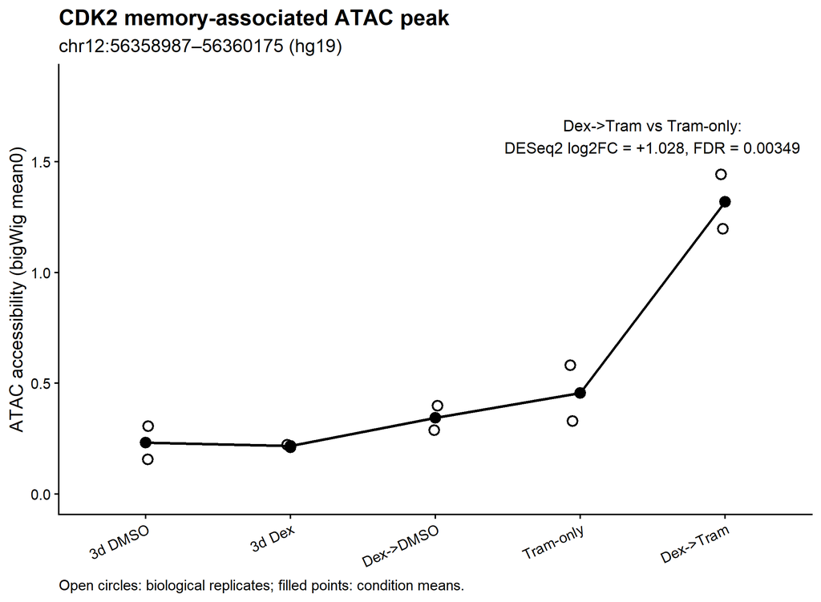

**Figure.** Accessibility trajectory at the statistically significant CDK2 memory-associated ATAC peak. Open circles represent biological replicates and filled points represent condition means. The DESeq2 statistic refers specifically to the Dex-to-Tram versus DMSO-to-Tram comparison.

# 17 IGV views for the nine kinase candidates

To complement the gene-body accessibility summaries, IGV snapshots were generated for each of the nine kinase candidate loci using the ATAC-seq bigWig tracks across the relevant conditions. These panels provide visual locus-level context and help assess whether accessibility changes arise from discrete local peaks rather than only from whole-gene averaged signal.

| Samples | Condition |
| --- | --- |
| J3, J16 | 3-day DMSO |
| J11, J15 | 3-day Dex |
| J4, J10 | Dex → DMSO |
| J6, J14 | DMSO → Tram |
| J18, J7 | Dex → Tram |

## 17.1 TESK2

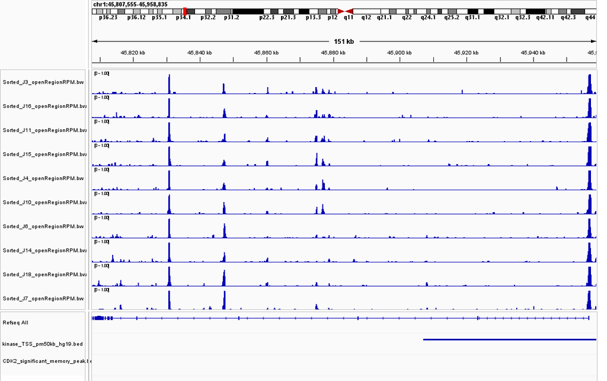

## 17.2 PRKCE

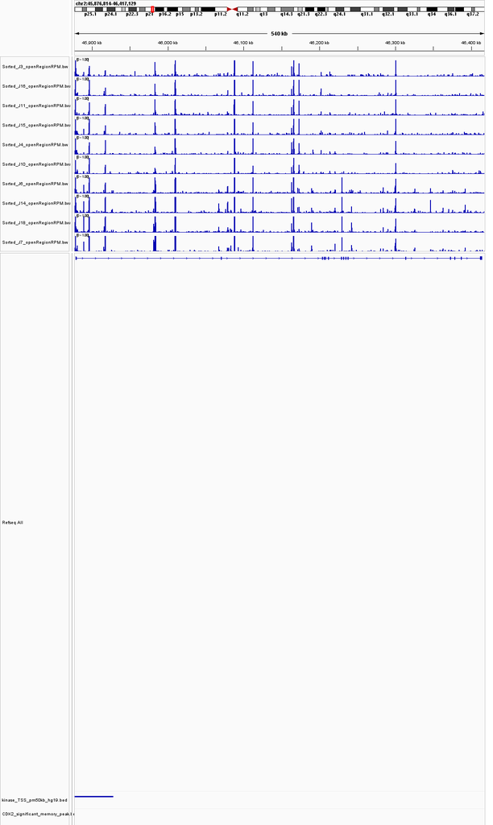

## 17.3 ACVR1C

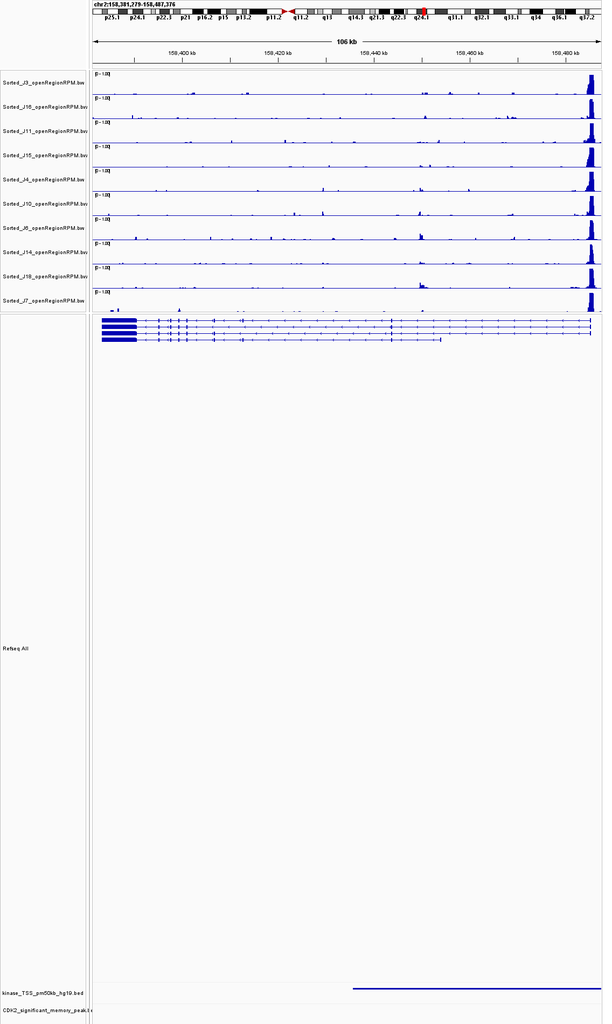

## 17.4 SNRK

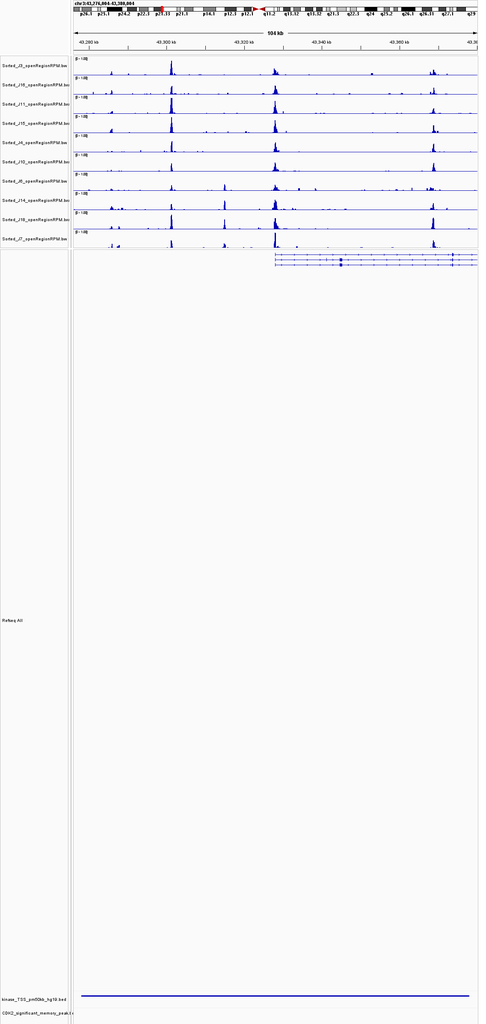

## 17.5 STK32A

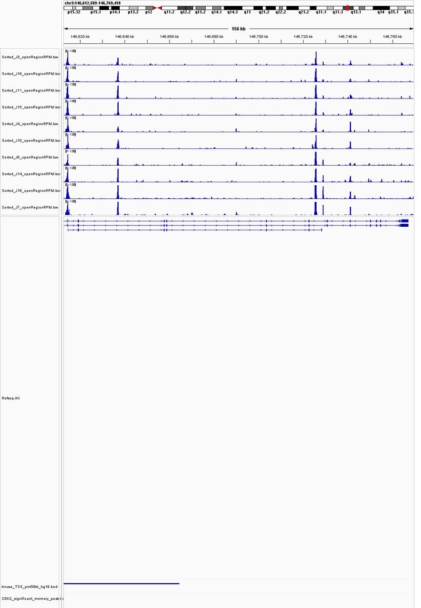

## 17.6 PIM1

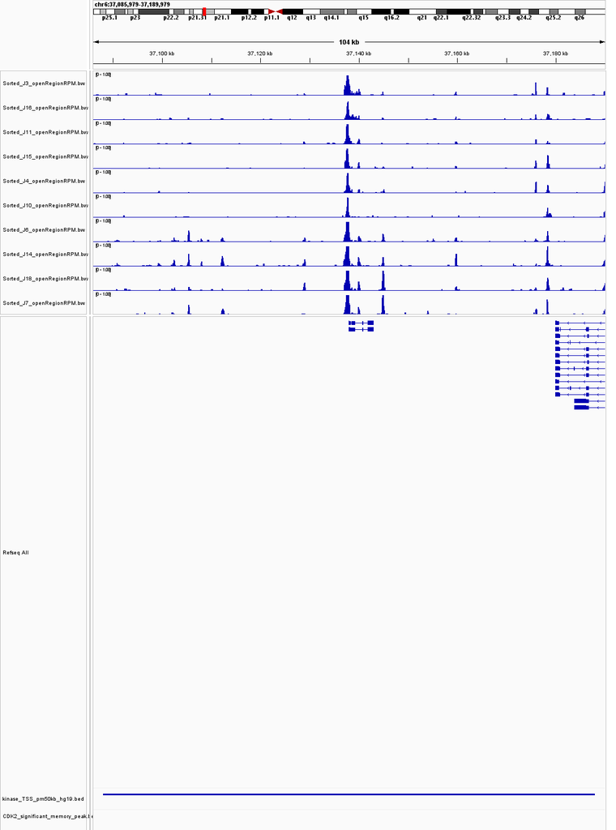

## 17.7 CDK2

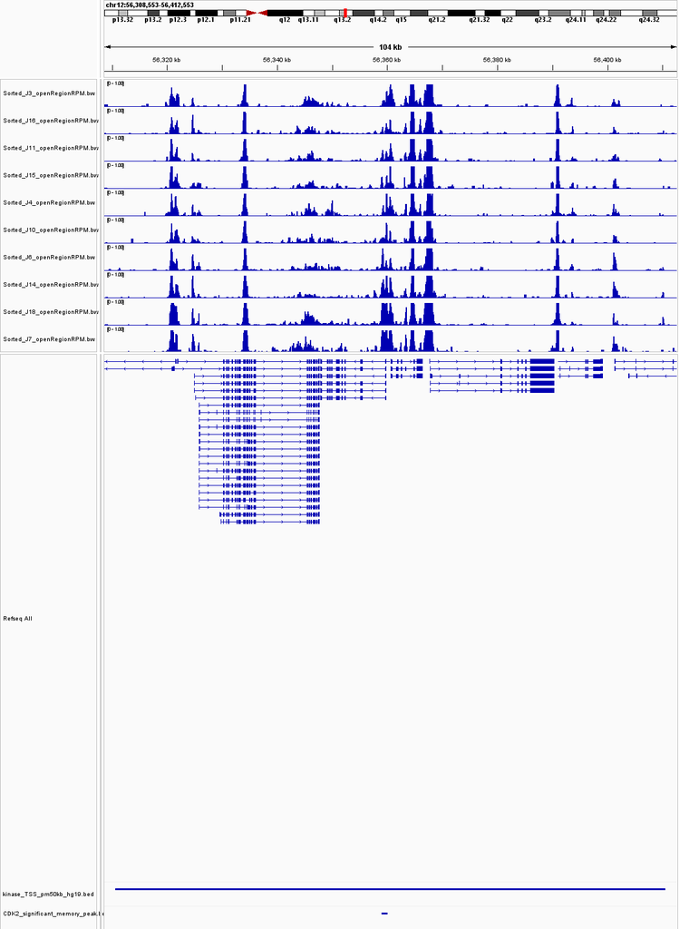

## 17.8 ERBB3

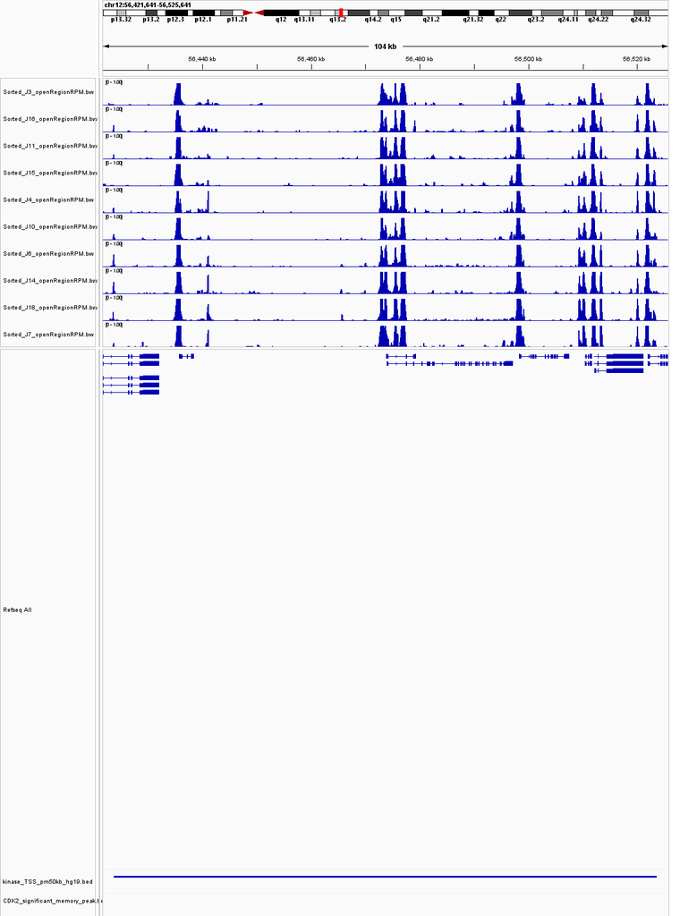

## 17.9 TRIB3

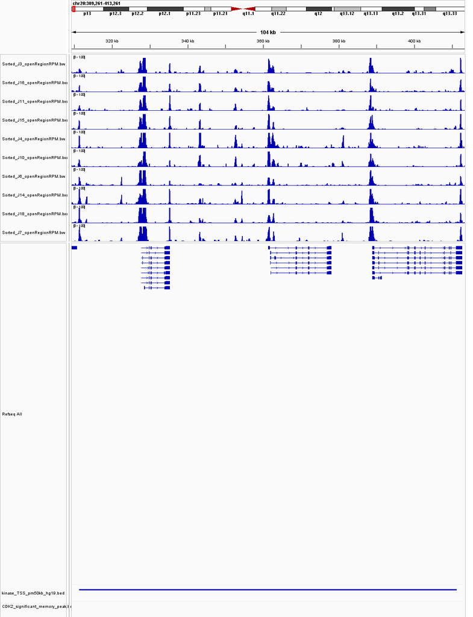

# 18 Zoomed IGV views of changed ATAC peaks

To directly examine local differential ATAC peaks, zoomed IGV views were generated for the five kinase loci that overlapped peaks reported in the authors’ Dex-to-Tram versus DMSO-to-Tram differential ATAC analysis.

These views focus on the local changed peak regions rather than accessibility averaged across the entire gene body.

Among these five kinase loci, only the CDK2 peak passed FDR < 0.05. The remaining peaks are shown for visual inspection but are not considered statistically significant after multiple-testing correction.

## 18.1 ACVR1C

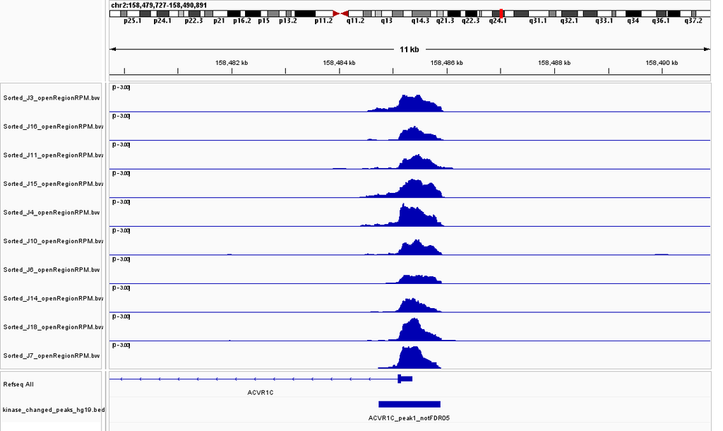

## 18.2 STK32A

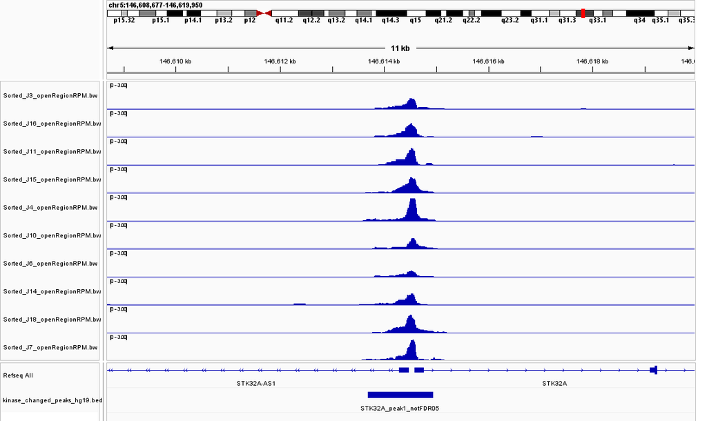

## 18.3 CDK2

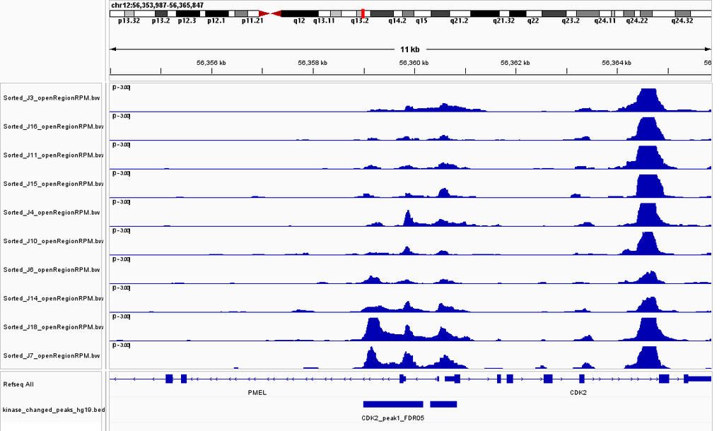

## 18.4 ERBB3

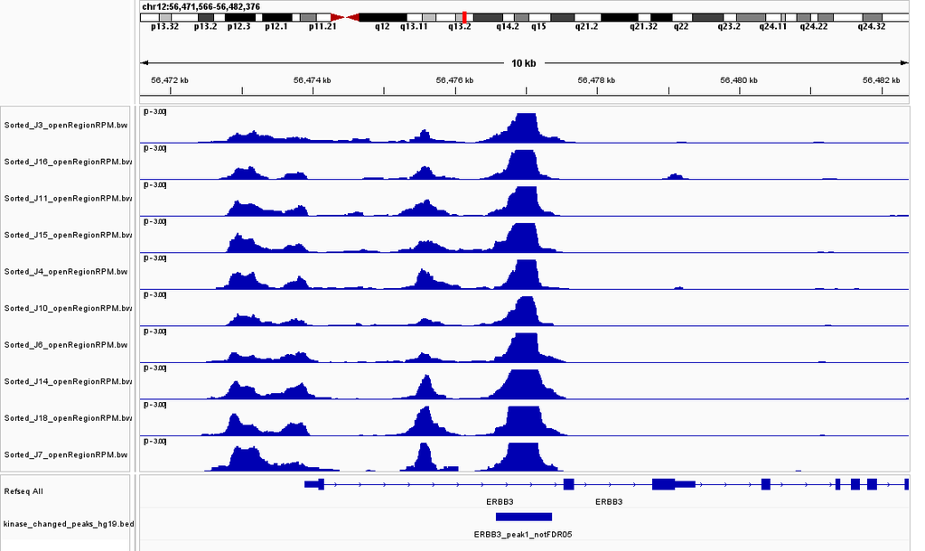

## 18.5 TRIB3

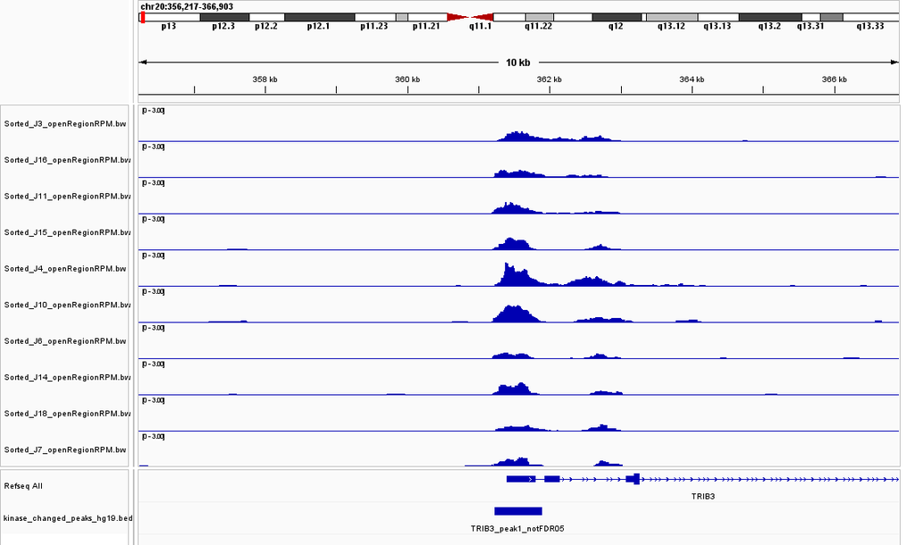

## 18.6 Peak-level interpretation

The reported differential ATAC peaks overlapping the kinase loci were:

- **ACVR1C:** one reported peak; not FDR-significant.
- **STK32A:** one reported peak; not FDR-significant.
- **CDK2:** two reported peaks, including one FDR-significant peak at `chr12:56358987-56360175` (log2FC = +1.028, FDR = 0.00349).
- **ERBB3:** one reported peak; not FDR-significant.
- **TRIB3:** one reported peak; not FDR-significant.

Thus, the zoomed IGV profiles provide visual evidence of the local ATAC signal, while formal statistical support for a memory-associated accessibility change is strongest for CDK2.